# Paired Sampling of SWA and Veg Across AOI

Aug-Sep; 2019, 2021, 2023

Matt Webster

…

```
The purposes of this script are as follows:

COMPLETE THE FOLLOWING FOR ALL TARGET WATERSHEDS (n=6) in 2019, 2021, 2023:

  1) Import and organize data from various sources/source scripts:
     ... for all riparian polygons in all watersheds:

    a) Surface water area (m2)
    b) Vegetation area (m2) & mean(NDVI)
    c) Riparian polygon geometries, and riparian polygon area (m2)
    d) Topographic Openness; Confinement (inverse TO)
    e) dynOcc data: grid cells, p, f, UDA
    f) Dam count
      - beaver dams ('certain' and 'all' detections)
      - anthropogenic dams/channel spanning structures (e.g., road crossings, check dams, etc.)

  2) Implement density based cluster analysis of dammed stream reaches
    a) Max distance to be considered same cluster (Eps) = 250(m)
    b) Minimum dams for one cluster (minPoints) = 1 dam

  3) Implement paired sampling of dammed and undammed reaches
    a) Dammed/undammed not within 500m of 'anthro'
    a2) Single dam = dam + 250m stream length (25 TP_ID)
    b) Undammed pair = same stream length as dammed
    c) Undammed not within 250m of 'dammed'
    d) Undammed not within 250m of 'undammed'
      - (force no overlap via spatial thinning, post pairing.
        This winnows your sample size)

  4) Compare surface water area (SWA), veg area (VA), and NDVI at dammed vs paired undammed reaches

  5) Visualize differences
```

## —-

[output not shown]

## Relative Flow Condition Across Study Period:

Visualize USGS flow data from Guston Coulee Gage on Beaver Ck, near Saco, MT.

Eventually, you’ll connect riparian inundation back to this for a post hoc heat map

Flow was z-standardized across [06/01-10/01] 2019, 2021, & 2023.

## Late Summer Flow Conditions

## 2019:

Moderate August with peak in September

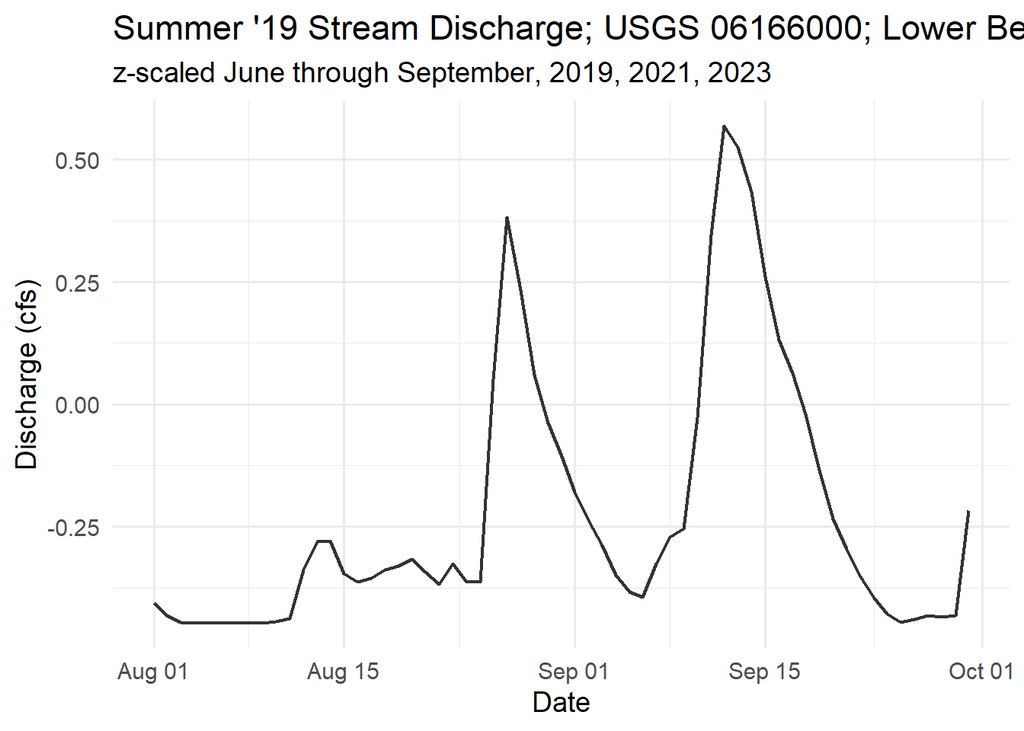

## 2021:

Low flow conditions throughout the summer season. Part of 3 year sustained drought conditions (2020, 2021, 2022).

Gage recorded no flow during August & September

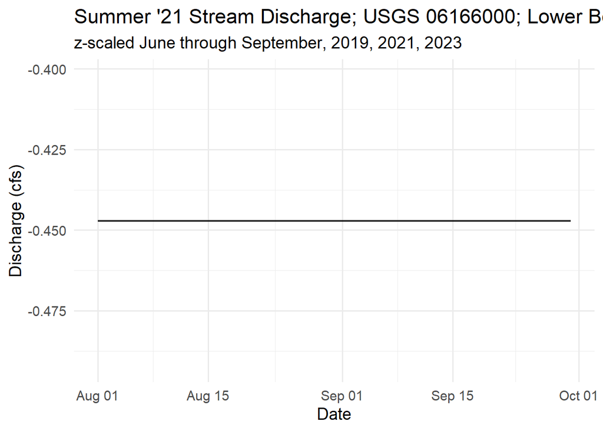

## 2023:

Moderate to low August & September flows; after early season extreme flooding.

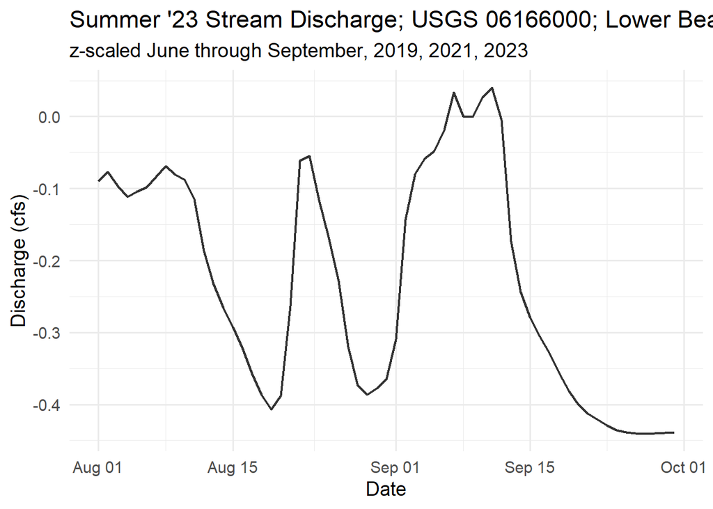

Visualize temporally static variables of interest:

```
These are variables that a constant per riparian polygon over time. TO and riparian area come from a 1m DEM from 2019, and are considered constant for our purposes. Ditto with catchment area, though it was derived from NHDplus-HR, I believe (double check with CP).
```

## Topographic Openness Across Study Area

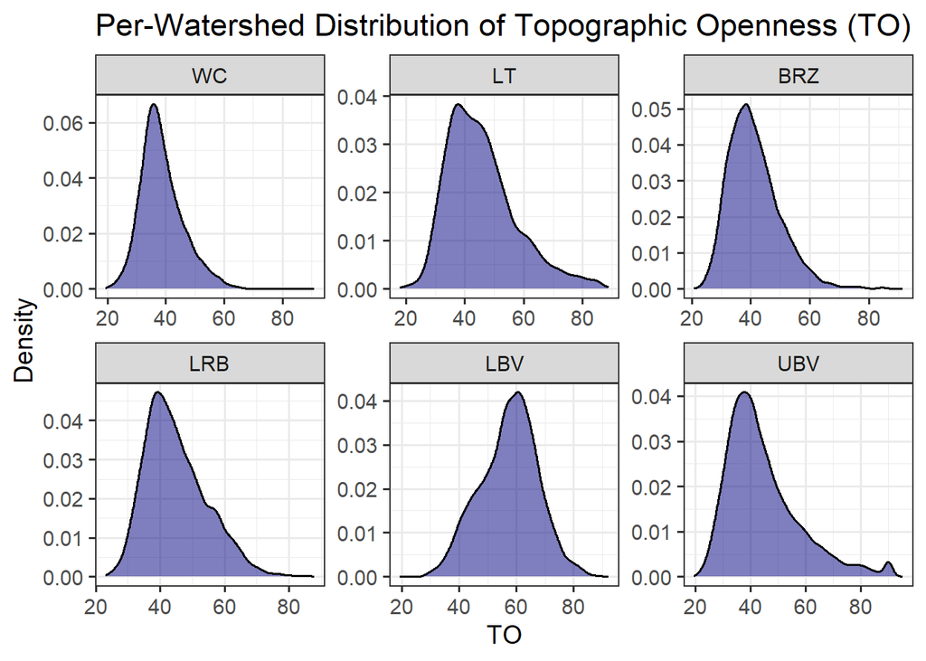

## Riparian Area Across Study Area

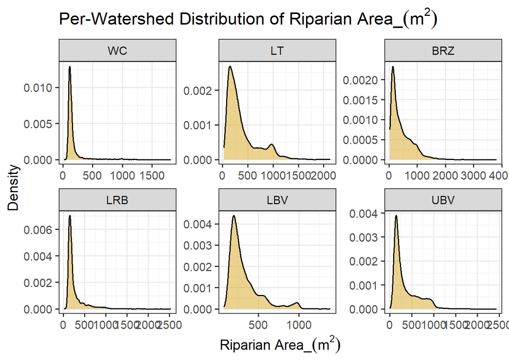

## Contributing Drainage Area Across Study Area

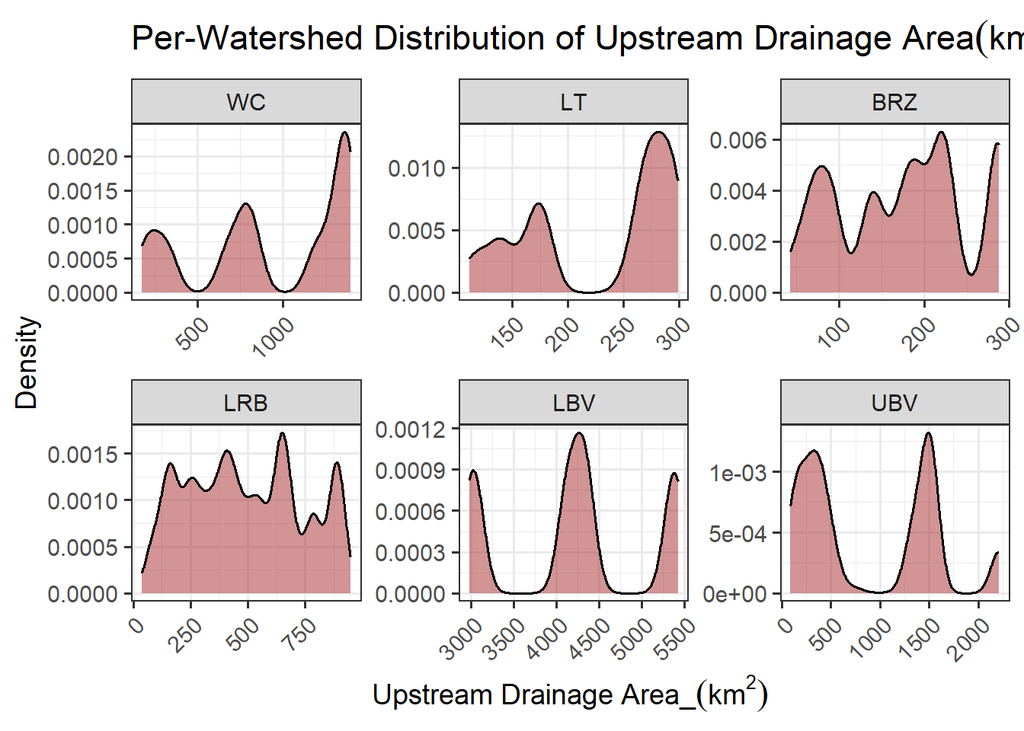

Get dam detections and surface water area for each riparian polygon, in each watershed, during each time period, in each year.

Dams [line 806:1811]

## —-

Identify dammed and undammed sample clusters using **1-D DBSCAN** (Density Based Spatial clustering Algorithm with Noise).

```
1-D DBSCAN uses TP_ID as a 1-D directional marker (following the stream flow
line). TP_IDs are ~10-m spaced. DBSCAN uses a minCluster size of 1 dam, and
a max distance for inclusion in a cluster of 250-m between dams.

Min(ClusterSize) = 1 dammed polygon
eps = 25


NOTE:
  - NOT DOING EPS[optimal] approach. Test clustering using 25 and test
    clustering using 10; Make a call.
  - Median distance between nearest neighbors is 300-m on Willow Ck 2021.
    Thus, less than 300m could be considered 'closer than normal';
    go with 250-m
  - At Eps=10 (100m search) just about every dam on WC21 is it's own cluster
    (155 dams, 126 clusters).
```

**Willow Creek**

**Lone Tree Creek**

**Brazil Creek**

**Larb Creek**

**LowBeav Creek**

**Upper Beav Creek**

```
## tibble [18,125 × 12] (S3: tbl_df/tbl/data.frame)
##  $ TP_ID              : num [1:18125] 1 2 3 4 5 6 7 8 9 10 ...
##  $ year               : num [1:18125] 2019 2019 2019 2019 2019 ...
##  $ unique_ID          : chr [1:18125] "UBV_1657" "UBV_1657" "UBV_1657" "UBV_1657" ...
##  $ TO                 : num [1:18125] 37.2 33.6 32.7 35.6 31.5 ...
##  $ catchment_km2      : num [1:18125] 2213 2213 2213 2213 2213 ...
##  $ p_mean             : num [1:18125] 0.907 0.907 0.907 0.907 0.907 ...
##  $ f_mean             : num [1:18125] 0.0194 0.0194 0.0194 0.0194 0.0194 ...
##  $ watershed          : chr [1:18125] "UBV" "UBV" "UBV" "UBV" ...
##  $ dam_count_beav_all : int [1:18125] 0 0 0 0 0 0 0 0 0 0 ...
##  $ dam_count_beav_conf: int [1:18125] 0 0 0 0 0 0 0 0 0 0 ...
##  $ dam_count_ant      : int [1:18125] 0 0 0 0 0 0 0 0 0 0 ...
##  $ isAnthro           : int [1:18125] 0 0 0 0 0 0 0 0 0 0 ...
```

**Implement DBSCAN:**

```
Criteria:
---------
  - minDams per Cluster = 1
  - eps = 250-m = 25-TP_ID

  - 'Beaver dammed' polygons must be >= 500-m from a 'anthropogenically
    dammed' polygon to limit the potential confounding effect on beaver v. non.
```

## WILLOW

**DEFINE PAIRED UNDAMMED REACHES:**

```
- Undammed sample reaches must be:
  - interspersed between dammed reaches
  - (>=) 250m from nearest dam window
    - ensure via 'tail' trim of undammed; post pairing
  - 'paired' with a nearby dam cluster
  - (>=) 250m from nearest undammed
    - forced thinning post-pairing
```

## **2019**

**Visualize Sample Reaches for Willow Creek 2019:**

[interactive chart not shown]

```
## [1] 22
```

## **2021**

**Visualize Sample Reaches for Willow Creek 2021:**

[interactive chart not shown]

```
## [1] 31
```

## **2023**

**Visualize Sample Reaches for Willow Creek 2023:**

[interactive chart not shown]

```
## [1] 18
```

## LONE TREE

**DEFINE PAIRED UNDAMMED REACHES:**

```
- Undammed sample reaches must be:
  - interspersed between dammed reaches
  - (>=) 250m from nearest dam
  - 'paired' with a nearby dam cluster
  - (>=) 250m from nearest undammed (forced thinning post-pairing)
```

## **2019**

**Visualize Sample Reaches for Lone Tree Creek 2019:**

[interactive chart not shown]

```
## [1] 10
```

## **2021**

**Visualize Sample Reaches for Lone Tree Creek 2021:**

[interactive chart not shown]

```
## [1] 10
```

## **2023**

**Visualize Sample Reaches for Lone Tree Creek 2023:**

[interactive chart not shown]

```
## [1] 15
```

## BRAZIL

**DEFINE PAIRED UNDAMMED REACHES:**

```
- Undammed sample reaches must be:
  - interspersed between dammed reaches
  - (>=) 250m from nearest dam
  - 'paired' with a nearby dam cluster
  - (>=) 250m from nearest undammed (forced thinning post-pairing)
```

## **2019**

**Visualize Sample Reaches for Brazil Creek 2019:**

[interactive chart not shown]

```
## [1] 13
```

## **2021**

**Visualize Sample Reaches for Brazil Creek 2021:**

[interactive chart not shown]

```
## [1] 13
```

## **2023**

**Visualize Sample Reaches for Brazil Creek 2023:**

[interactive chart not shown]

```
## [1] 16
```

## LARB

**DEFINE PAIRED UNDAMMED REACHES:**

```
- Undammed sample reaches must be:
  - interspersed between dammed reaches
  - (>=) 250m from nearest dam
  - 'paired' with a nearby dam cluster
  - (>=) 250m from nearest undammed (forced thinning post-pairing)
```

## **2019**

**Visualize Sample Reaches for Larb Creek 2019:**

[interactive chart not shown]

```
## [1] 19
```

## **2021**

**Visualize Sample Reaches for Larb Creek 2021:**

[interactive chart not shown]

```
## [1] 24
```

## **2023**

**Visualize Sample Reaches for Larb Creek 2023:**

[interactive chart not shown]

```
## [1] 16
```

## LOW BEAV

**DEFINE PAIRED UNDAMMED REACHES:**

```
- Undammed sample reaches must be:
  - interspersed between dammed reaches
  - (>=) 250m from nearest dam
  - 'paired' with a nearby dam cluster
  - (>=) 250m from nearest undammed (forced thinning post-pairing)
```

## **2019**

**Visualize Sample Reaches for Lower Beaver Creek 2019:**

[interactive chart not shown]

```
## [1] 2
```

## **2021**

**Visualize Sample Reaches for Lower Beaver Creek 2021:**

[interactive chart not shown]

```
## [1] 11
```

## **2023**

**Visualize Sample Reaches for Lower Beaver Creek 2023:**

[interactive chart not shown]

```
## [1] 22
```

## UPPER BEAVER

**DEFINE PAIRED UNDAMMED REACHES:**

```
- Undammed sample reaches must be:
  - interspersed between dammed reaches
  - (>=) 250m from nearest dam
  - 'paired' with a nearby dam cluster
  - (>=) 250m from nearest undammed (forced thinning post-pairing)
```

## **2019**

**Visualize Sample Reaches for Upper Beaver Creek 2019:**

[interactive chart not shown]

```
## [1] 24
```

## **2021**

**Visualize Sample Reaches for Upper Beaver Creek 2021:**

[interactive chart not shown]

```
## [1] 42
```

## **2023**

**Visualize Sample Reaches for Upper Beaver Creek 2023:**

[interactive chart not shown]

```
## [1] 30
```

## —-

Surface Water Area

**Willow Creek**

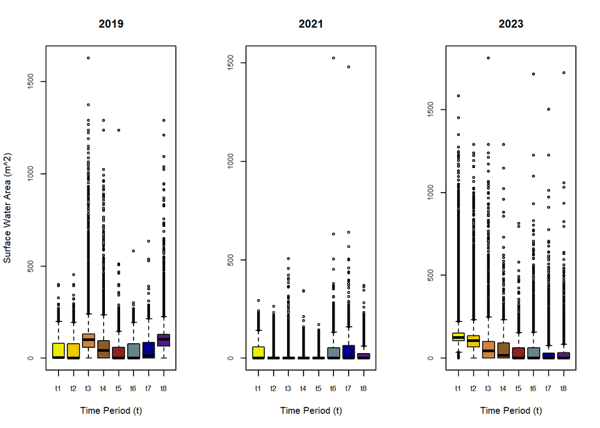

**Lone Tree Creek**

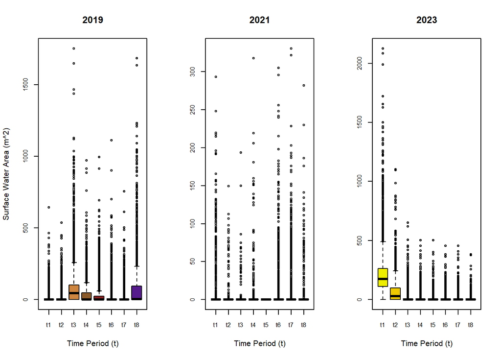

**Brazil Creek**

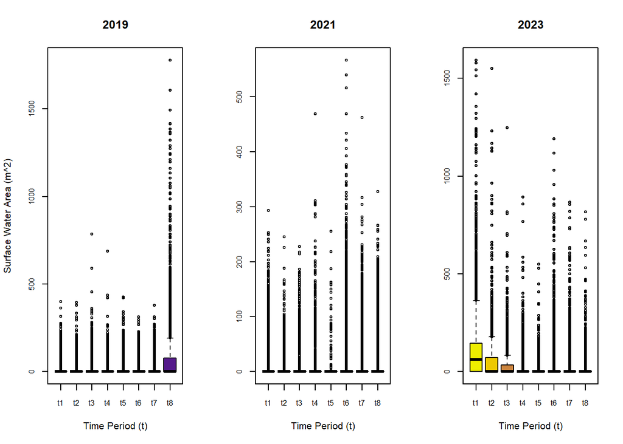

**Larb Creek**

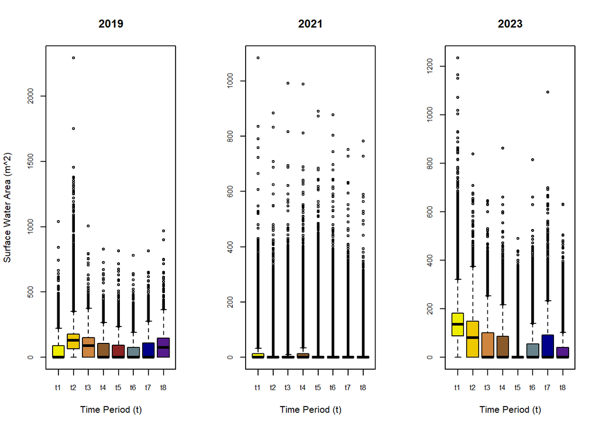

**Lower Beaver Creek**

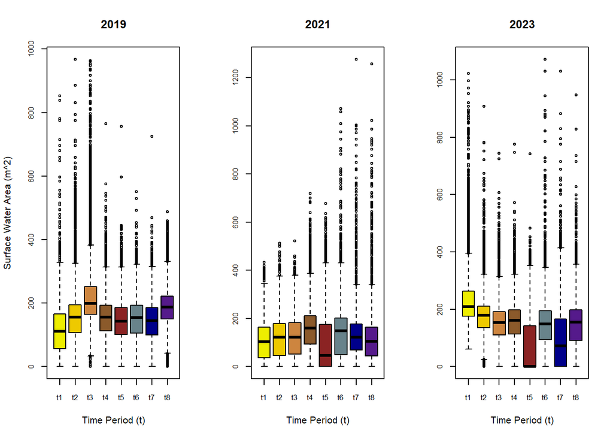

**Upper Beaver Creek**

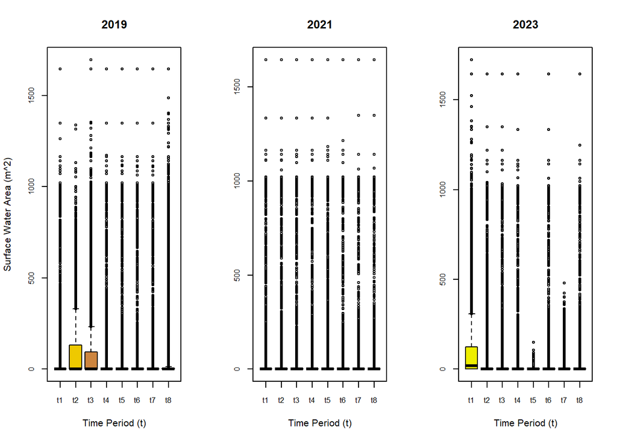

## —-

Now sample SWA and VEG for dammed and undammed clusters, and finalize data frames for summary and analysis:

```
The goal is to end up with a dataframe in long format where columns =

  - ClusterID_seq: (1:n)
  - Window_type: 'dammed' v 'undammed'
  - sum_c: summed dam count for window
  - mean_p: avg det prob for window
  - mean_f: avg fp prob for window
  - Nhat: est. dam count, considering mean(p,fp)
  - TO_mean: mean TO for window
  - RIP_Area_m2: total riparian area in (m^2)
  - UDA: contributing catchment area in (km^2)
  - containsNull: Impacted by satellite obfuscation
  - timePeriod: sample period 1:8; 2wk subdivisions of (June 01 - Sept 30).
  - SWA: summed surface water area of window
  - NDVI: mean(NDVI) of window
  - NDVIsd: sd(NDVI) of window
  - VA: summed veg area of window
  -
```

## **WILLOW**

## **2019**

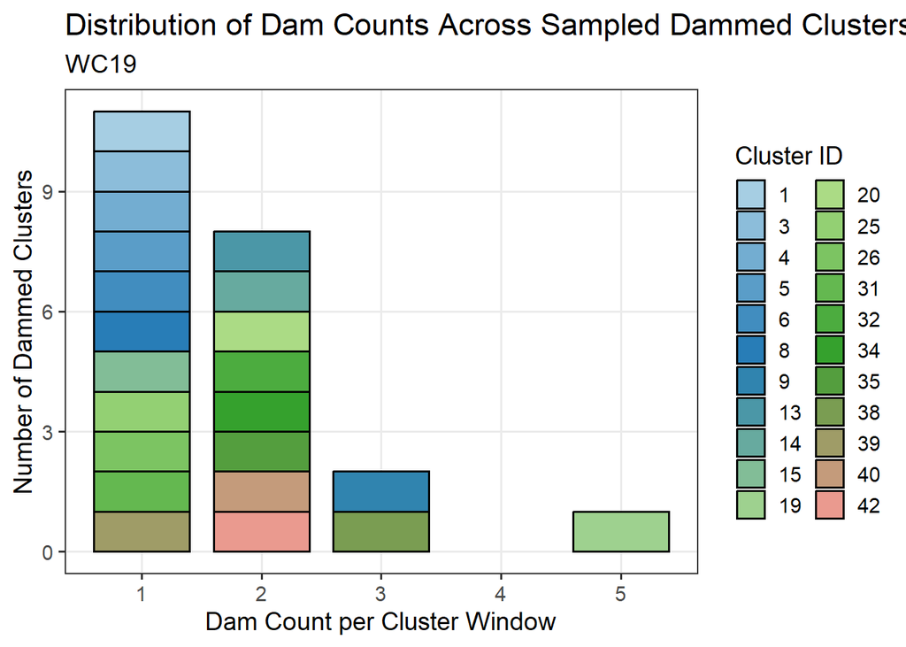

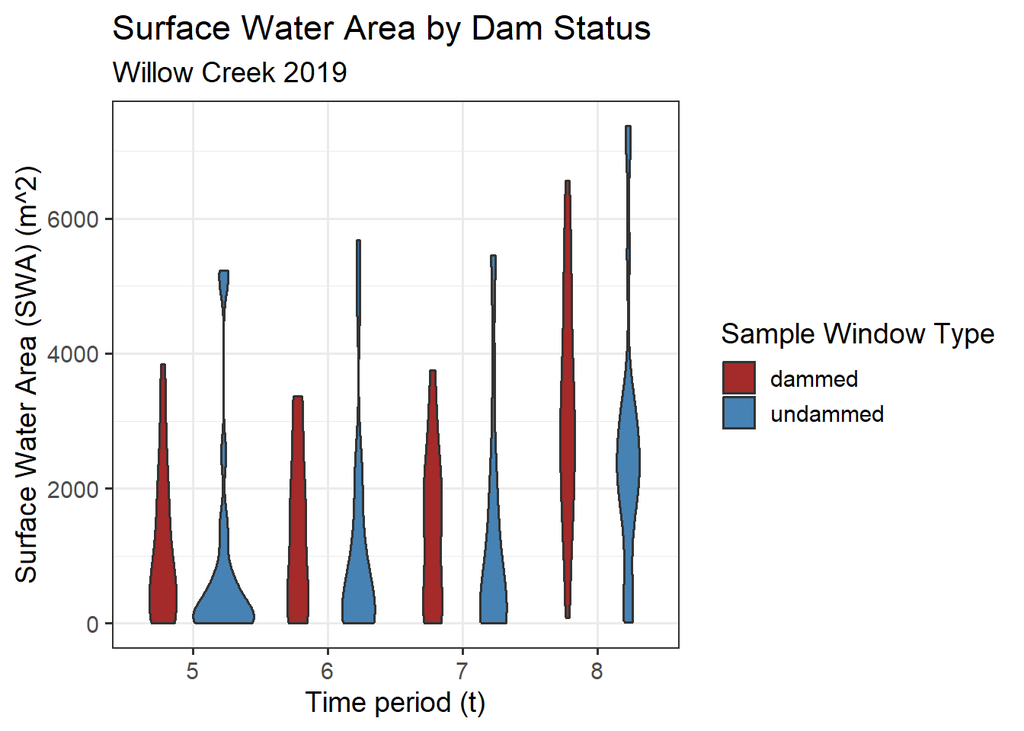

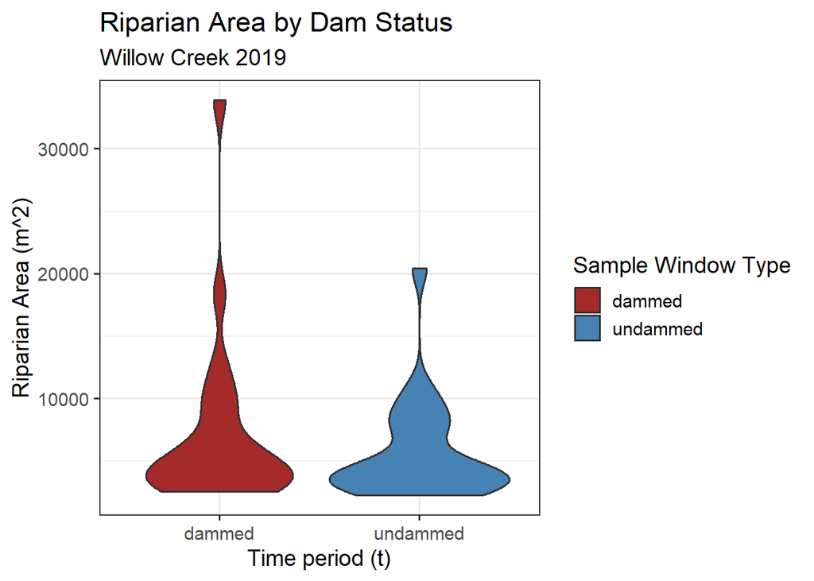

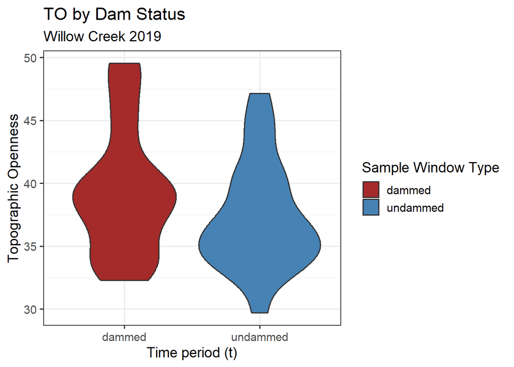

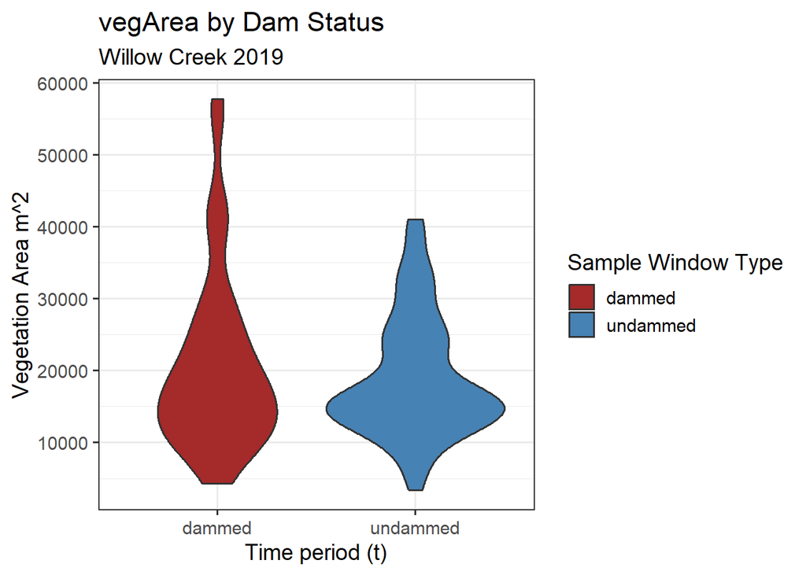

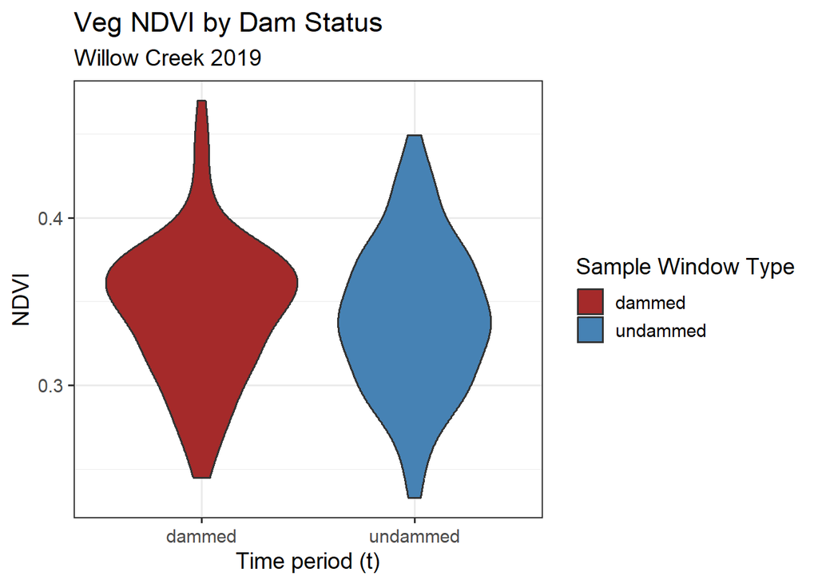

## **2021**

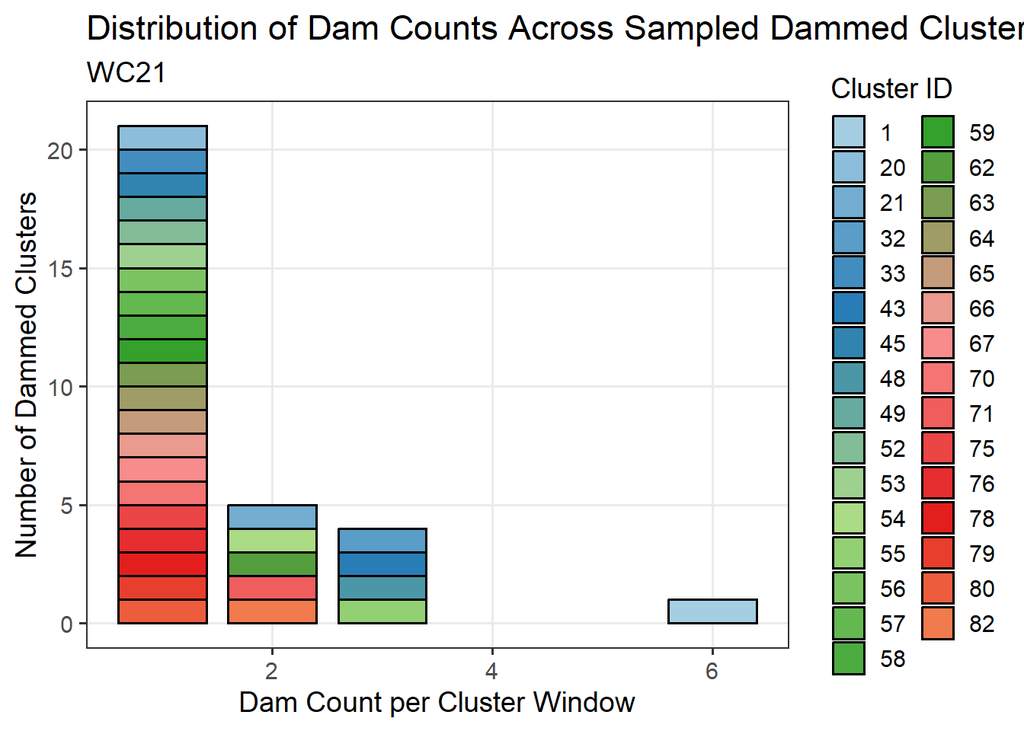

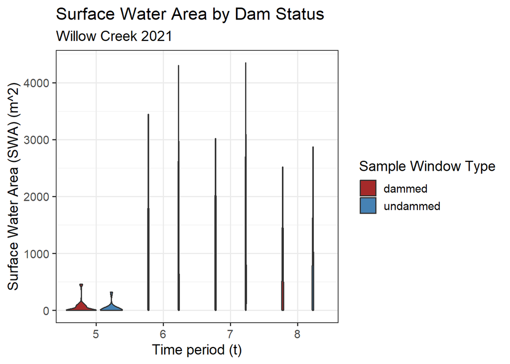

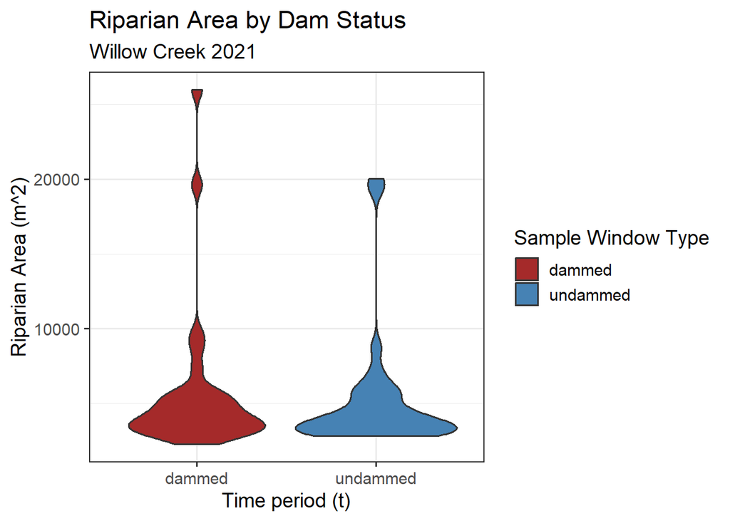

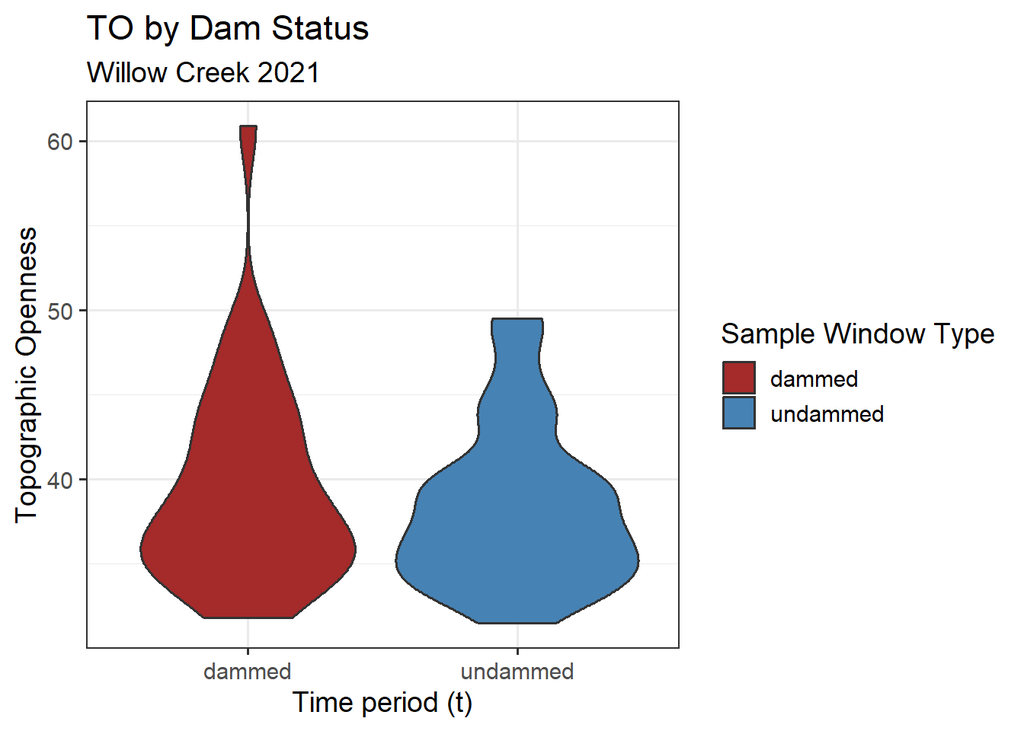

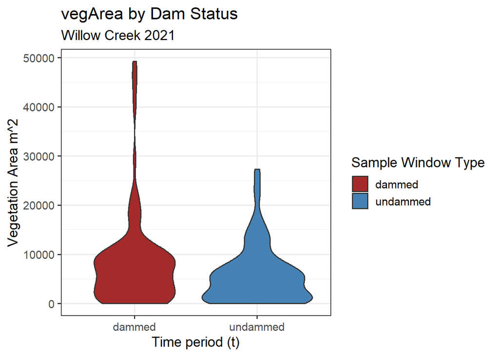

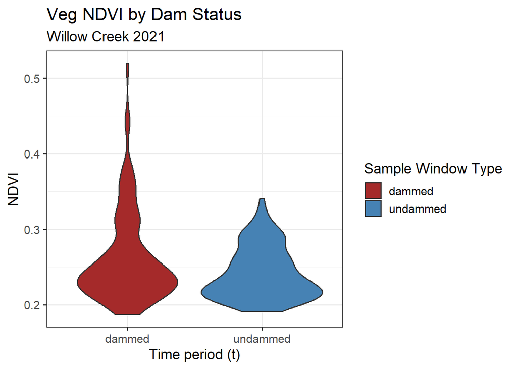

## **2023**

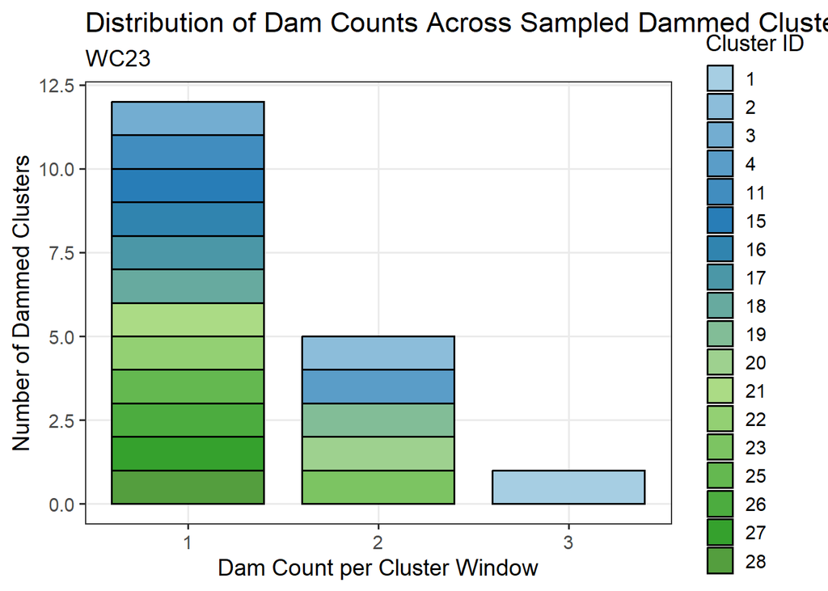

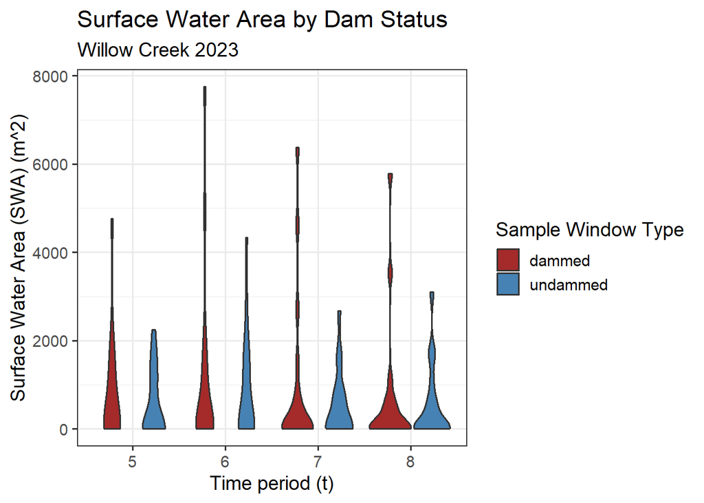

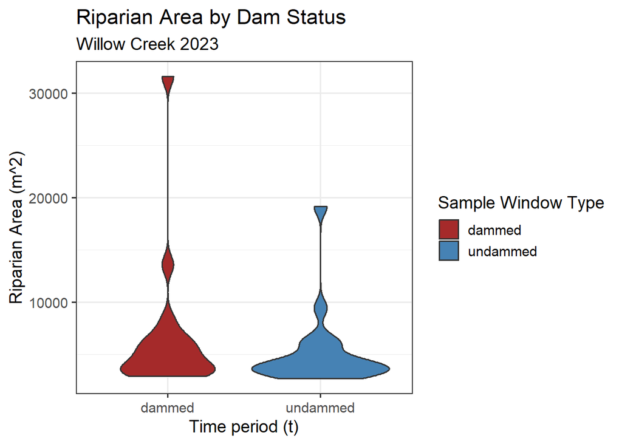

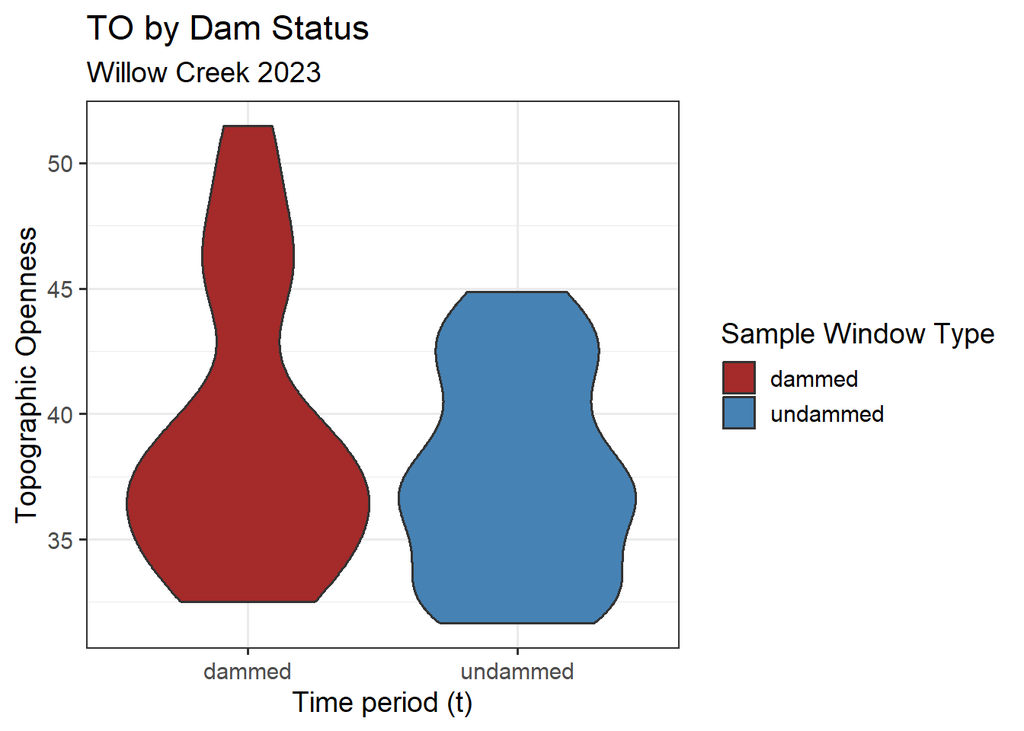

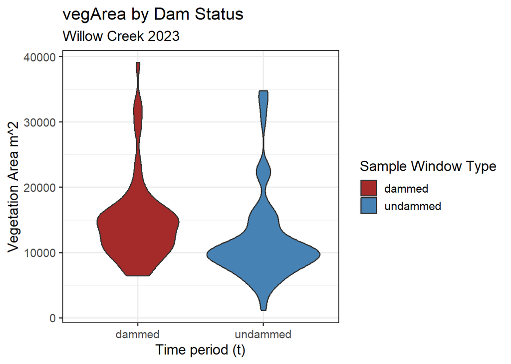

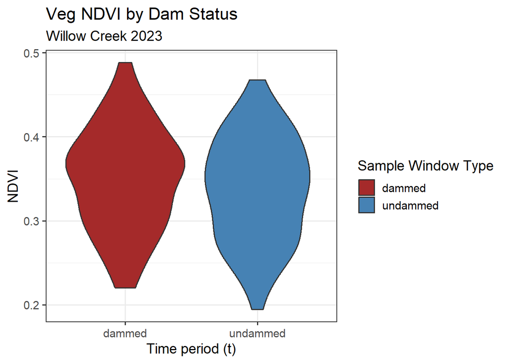